# Predi??o de Deputados Eleitos

Diogo Flor?ncio

1 de mar?o de 2018

```r
library(tidyverse)
library(caret)
library(ROSE)
library(missForest)
options(scipen = 4) #escala dos valores exibidos
data <- read.csv("../dados/train_lab4.csv", encoding = "UTF-8")

# Separa os dados em treino e teste
dataPartition <- createDataPartition(y = data$situacao_final, p=0.75, list=FALSE)
# Se o y for um vector de factor a divis?o ? feita tentando balancear a distribui??o de classes de # y dentro das parti??es.

train <- data[ dataPartition, ]
validation <- data[ -dataPartition, ]
```

Os dados de treino apresentam muitos valores faltantes representados por `0`, para resolver este problema Utilizei o m?todo missForest, do pacote missForest. Este m?todo constro? um modelo de `floresta aleat?ria` para cada vari?vel e ent?o utliza para prever os valores das vari?veis faltantes por meio dos valores observados.

Algumas vari?veis irrelevantes foram removidas como `ID` e `nome`.

```r
#removendo vari?veis irrelevantes
train <- train %>% select(-ID, -nome, -numero_cadidato, -setor_economico_receita, -setor_economico_despesa)
validation <- validation %>% select(-ID, -nome, -numero_cadidato, -setor_economico_receita, -setor_economico_despesa)
#o m?todo missForest n?o executa para vari?veis com mais de 53 categorias, neste caso optei por remover a vari?vel descricao_ocupacao
train <- train %>% select(-descricao_ocupacao)
validation <- validation %>% select(-descricao_ocupacao)
#transformando valores faltantes em NA
train[train == 0] <- NA
validation[validation == 0] <- NA
#tratando missing data
train <- missForest(train)$ximp
```

```
  missForest iteration 1 in progress...done!
  missForest iteration 2 in progress...done!
  missForest iteration 3 in progress...done!
```

```r
validation <- missForest(validation)$ximp
```

```
  missForest iteration 1 in progress...done!
  missForest iteration 2 in progress...done!
  missForest iteration 3 in progress...done!
  missForest iteration 4 in progress...done!
```

## H? desbalanceamento das classes (isto ?, uma classe tem muito mais inst?ncias que outra)? Em que propor??o? Quais efeitos colaterais o desbalanceamento de classes pode causar no classificador?.

Classes desbalanceadas ocorrem quando existe uma grande despropor??o entre o n?mero de exemplos de cada classe. Essa situa??o frequentemente faz com que os exemplos da classe minorit?ria sejam classificados incorretamente.

```r
prop.table(table(train$situacao_final))
```

```
    eleito nao_eleito
 0.1005803  0.8994197
```

Analisando os dados de treino ? f?cil perceber o grande desbalanceamento entre classes, neste caso a classe `nao_eleitos` compreende aproximadamente 90% dos exemplos de treino.

Para resolver esse problema utilizei o m?todo de balanceamento ROSE, do pacote ROSE, este m?todo gera dados de forma sint?tica buscando preservar as caracter?sticas dos dados originais.

```r
train <- ROSE(situacao_final ~ ., data = train, seed = 1)$data
prop.table(table(train$situacao_final))
```

```
nao_eleito     eleito
 0.5206319  0.4793681
```

Agora as classes apresentam uma quantidade proporcional de exemplos, `nao_eleitos` 52% e `eleitos` 48%.

## Treine: um modelo de regress?o log?stica, uma ?rvore de decis?o e um modelo de adaboost. Tune esses modelos usando valida??o cruzada e controle overfitting se necess?rio, considerando as particularidades de cada modelo.

### Regress?o Log?stica

O modelo de regress?o log?stica foi tunado conforme a fun??o definida em `fitcontrol`, o hiperparametro do modelo ? otimizado por meio de testes em `n` valores aleat?rios. Todos os modelos consideram 5-fold para valida??o cruzada.

```r
fitControl <- trainControl(method = "cv",
                    number = 5,
                    search= "random")

formula <- as.formula(situacao_final ~.)

# Regress?o log?stica glm (generalized linear model)
reg_log <- train(formula,
                 data = train,
                 method="glm",
                 trControl = fitControl,
                 family="binomial",
                 na.action = na.omit)
```

### ?rvore de decis?o

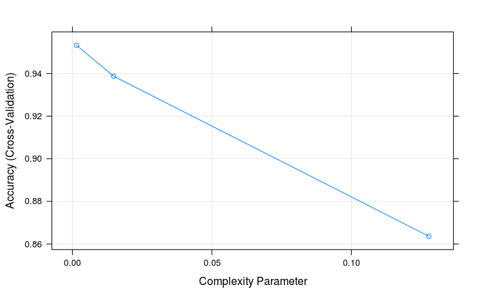

```r
#intervalo do hiperpar?metro
values_cp <- expand.grid(fraction = seq(0, 0.01, length = 10))
arvore <- train(formula,
                 data=train,
                 method = "rpart",
                 trControl = fitControl,
                 cp = values_cp,  # hiperpar?metro de complexidade
                 maxdepth = 20,
                 na.action = na.omit)
plot(arvore)
```

O melhor valor observado foi para um `cp` de aproximadamente 0.0012.

### Modelo Adaboost

O modelo adaboost foi tunado por meio do teste de `n` valores para seu hiperpar?metro `n?mero de ?rvores`.

```r
adaboost <- train(formula,
                  data=train,
                  method = "adaboost",
                  trControl = fitControl,
                  na.action = na.omit)
plot(adaboost)
```

[output not shown]

## Reporte acur?cia, precision, recall e f-measure no treino e valida??o. Como voc? avalia os resultados? Justifique sua resposta.

### Regress?o log?stica

```r
train$predict <- predict(reg_log, train)
confusionMatrix(train$predict, train$situacao_final)
```

```
Confusion Matrix and Statistics

            Reference
Prediction   nao_eleito eleito
  nao_eleito       1471    172
  eleito            144   1315

               Accuracy : 0.8981
                 95% CI : (0.8869, 0.9086)
    No Information Rate : 0.5206
    P-Value [Acc > NIR] : <2e-16

                  Kappa : 0.7958
 Mcnemar's Test P-Value : 0.1288

            Sensitivity : 0.9108
            Specificity : 0.8843
         Pos Pred Value : 0.8953
         Neg Pred Value : 0.9013
             Prevalence : 0.5206
         Detection Rate : 0.4742
   Detection Prevalence : 0.5297
      Balanced Accuracy : 0.8976

       'Positive' Class : nao_eleito
```

```r
validation$predict <- predict(reg_log, validation)
confusionMatrix(validation$predict, validation$situacao_final)
```

```
Levels are not in the same order for reference and data. Refactoring data to match.
```

```
Confusion Matrix and Statistics

            Reference
Prediction   eleito nao_eleito
  eleito         92         70
  nao_eleito     12        859

               Accuracy : 0.9206
                 95% CI : (0.9024, 0.9364)
    No Information Rate : 0.8993
    P-Value [Acc > NIR] : 0.0112

                  Kappa : 0.6486
 Mcnemar's Test P-Value : 3.082e-10

            Sensitivity : 0.88462
            Specificity : 0.92465
         Pos Pred Value : 0.56790
         Neg Pred Value : 0.98622
             Prevalence : 0.10068
         Detection Rate : 0.08906
   Detection Prevalence : 0.15682
      Balanced Accuracy : 0.90463

       'Positive' Class : eleito
```

### ?rvore de decis?o

```r
train$predict <- predict(arvore, train)
confusionMatrix(train$predict, train$situacao_final)
```

```
Confusion Matrix and Statistics

            Reference
Prediction   nao_eleito eleito
  nao_eleito       1542     12
  eleito             73   1475

               Accuracy : 0.9726
                 95% CI : (0.9662, 0.9781)
    No Information Rate : 0.5206
    P-Value [Acc > NIR] : < 2.2e-16

                  Kappa : 0.9452
 Mcnemar's Test P-Value : 7.62e-11

            Sensitivity : 0.9548
            Specificity : 0.9919
         Pos Pred Value : 0.9923
         Neg Pred Value : 0.9528
             Prevalence : 0.5206
         Detection Rate : 0.4971
   Detection Prevalence : 0.5010
      Balanced Accuracy : 0.9734

       'Positive' Class : nao_eleito
```

```r
validation$predict <- predict(arvore, validation)
confusionMatrix(validation$predict, validation$situacao_final)
```

```
Levels are not in the same order for reference and data. Refactoring data to match.
```

```
Confusion Matrix and Statistics

            Reference
Prediction   eleito nao_eleito
  eleito         77         28
  nao_eleito     27        901

               Accuracy : 0.9468
                 95% CI : (0.9313, 0.9596)
    No Information Rate : 0.8993
    P-Value [Acc > NIR] : 0.0000000264

                  Kappa : 0.7072
 Mcnemar's Test P-Value : 1

            Sensitivity : 0.74038
            Specificity : 0.96986
         Pos Pred Value : 0.73333
         Neg Pred Value : 0.97091
             Prevalence : 0.10068
         Detection Rate : 0.07454
   Detection Prevalence : 0.10165
      Balanced Accuracy : 0.85512

       'Positive' Class : eleito
```

### Adaboost

```r
train$predict <- predict(adaboost, train)
confusionMatrix(train$predict, train$situacao_final)
```

[output not shown]

```r
validation$predict <- predict(adaboost, validation)
confusionMatrix(validation$predict, validation$situacao_final)
```

[output not shown]

## Interprete as sa?das dos modelos. Quais atributos parecem ser mais importantes de acordo com cada modelo? Crie pelo menos um novo atributo que n?o est? nos dados originais e estude o impacto desse atributo.

Os gr?ficos exibem as 10 vari?veis mais importantes por ordem de import?ncia para cada modelo.

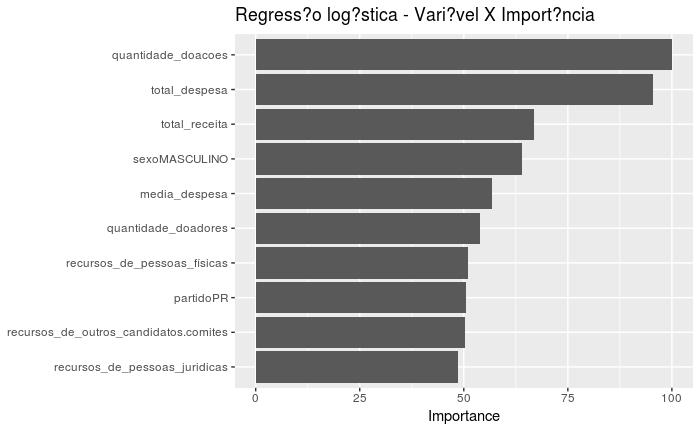

```r
ggplot(varImp(reg_log), top = 10) +
theme(axis.title.y=element_blank()) +
ggtitle("Regress?o log?stica - Vari?vel X Import?ncia")
```

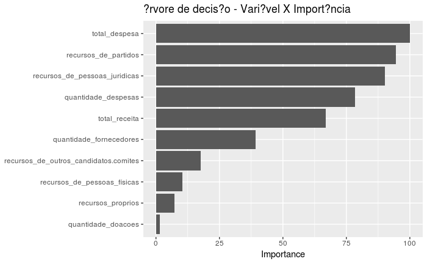

```r
ggplot(varImp(arvore), top = 10) +
theme(axis.title.y=element_blank()) +
ggtitle("?rvore de decis?o - Vari?vel X Import?ncia")
```

```r
ggplot(varImp(adaboost), top = 10) +
theme(axis.title.y=element_blank()) +
ggtitle("Adaboost - Vari?vel X Import?ncia")
```

[output not shown]

## Envie seus melhores modelos ? competi??o do Kaggle.

```r
test <- read.csv("../dados/test_lab4.csv", encoding = "UTF-8")
submission <- read.csv("../dados/sample_submission_lab4.csv")

submission_predict <- predict(adaboost, test)

for(i in 1:length(submission_predict)){
  print(submission_predict[i])
  submission$prediction[i] = submission_predict[i]
}

write.csv(submission, file = "../dados/submission.csv", row.names = FALSE)
```